# Function Translations

Mr. Worley

# Puzzle 1

| $x$ | $f(x)$ |
| --- | --- |
| 1 | -50 |
| 2 | 34 |
| 3 | 70 |
| 4 | 33 |
| 5 | -22 |
| 6 | 61 |
| 7 | -69 |
| 8 | 73 |
| 9 | -62 |

Let $a=6$. Evaluate $f(a+2)$.

- Solution: substitute $6$ for $a$ in the expression.
  $$f(a+2)~=~f(6+2)$$
- Simplify the argument with arithmetic.
  $$f(a+2)~=~f(8)$$
- Use the table to determine that $f(8)=73$.
  $$f(a+2)~=~73$$

# Puzzle 2

| $x$ | $f(x)$ |
| --- | --- |
| 1 | -50 |
| 2 | 34 |
| 3 | 70 |
| 4 | 33 |
| 5 | -22 |
| 6 | 61 |
| 7 | -69 |
| 8 | 73 |
| 9 | -62 |

Let $a=6$. Evaluate $f(a)+2$.

- Solution: substitute $6$ for $a$ in the expression.
  $$f(a)+2~=~f(6)+2$$
- Use the table to determine that $f(6)=61$. Substitute.
  $$f(a)+2~=~61+2$$
- Use arithmetic.
  $$f(a)+2=63$$

# Puzzle 3

| $x$ | $f(x)$ |
| --- | --- |
| 1 | -50 |
| 2 | 34 |
| 3 | 70 |
| 4 | 33 |
| 5 | -22 |
| 6 | 61 |
| 7 | -69 |
| 8 | 73 |
| 9 | -62 |

Let $a=6$. Evaluate $f(a-2)+3$.

- Solution: substitute $6$ for $a$ in the expression.
  $$f(a-2)+3~=~f(6-2)+3$$
- Use arithmetic to simplify the argument.
  $$f(a-2)+3~=~f(4)+3$$
- Use the table.
  $$f(a-2)+3~=~33+3$$
- Use arithmetric to simplify.
  $$f(a-2)+3~=~36$$

# Classwork Break

https://bart.instructure.com/courses/2110/quizzes/3157

# Horizontal Translation

Let function $f$ be defined with the following table:

| $x$ | $f(x)$ |
| --- | --- |
| 4 | 22 |
| 5 | 29 |
| 6 | 21 |
| 7 | 27 |
| 8 | 25 |
| 9 | 28 |

Let another function, $g$, be defined:

$$g(x)~=~f(x+2)$$

Using all the information in the first table, we wish to create a new table for $g$.

| $x$ | $g(x)$ |
| --- | --- |

- We might start by using $x=4$.
- We use the definition of $g$, replacing all $x$ values with $4$.
  $$g(4)=f(4+2)$$
- We can simplify the expression in the argument of $f$.
  $$g(4)=f(6)$$
- We know the value of $f(6)$…
  $$f(6)=21$$
- And, thus,
  $$g(4)=21$$

  | $x$ | $g(x)$ |
  | --- | --- |
  | 4 | 21 |

- Can you predict what the whole table for $g$ will look like?
- Notice, the effect was simply to reduce each $x$ value by 2.

  | $x$ | $g(x)$ |
  | --- | --- |
  | 2 | 22 |
  | 3 | 29 |
  | 4 | 21 |
  | 5 | 27 |
  | 6 | 25 |
  | 7 | 28 |

- If we make a graph of both $y=f(x)$ and $y=g(x)$, what is the transformation that explains how to get $g$ from $f$?
- If we shift $y=f(x)$ to the left by 2 units, we get $y=g(x)$. Notice this is a bit confusing, because of the plus symbol in the definition $g(x)=f(x+2)$, you might (incorrectly) think we should add two to each $x$ value. The reason for the leftward shift is based on needing the argument of $f$ to equal a specific value. For example, for the argument of $f$ to equal 5, we need $x+2=5$, which we solve by **subtracting** 2 from both sides.

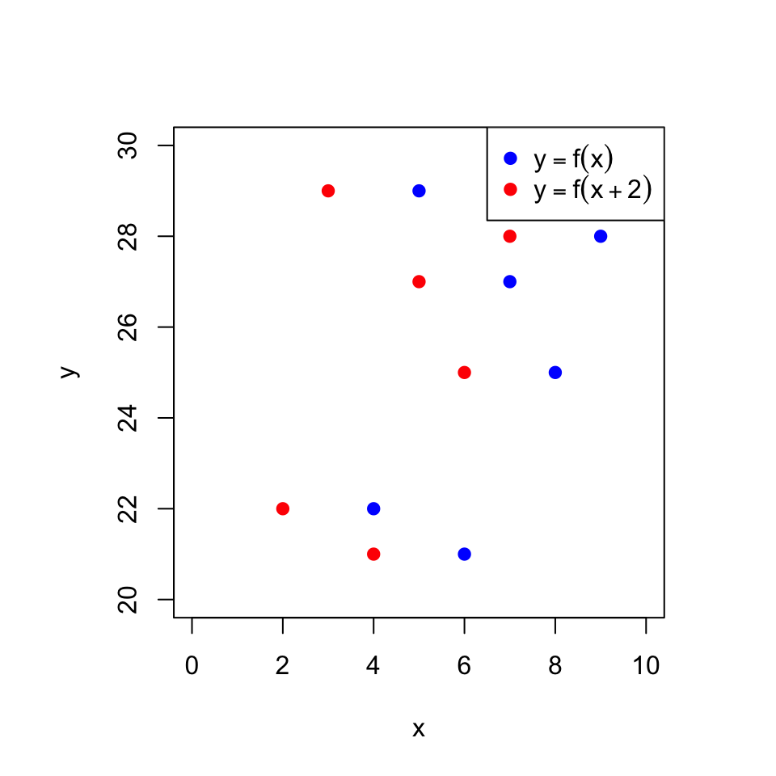

# Practice Problem 1

A function $f$ is graphed below as $y=f(x)$.

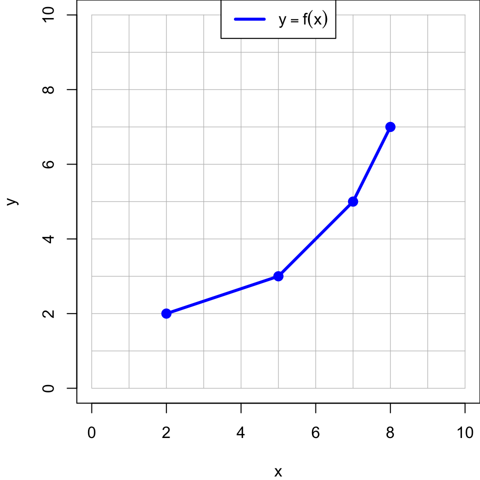

Please sketch $y=f(x-2)$.

- We can first get a list of coordinates from the $y=f(x)$ curve.

  | $x$ | $f(x)$ |
  | --- | --- |
  | 2 | 2 |
  | 5 | 3 |
  | 7 | 5 |
  | 8 | 7 |

- Now, we can generate another table… keep in mind: this table’s $x$ values are not the same as the old table’s $x$ values. We are allowed to do this… The goal is to find values of $x$ that make the argument (which is $x-2$ in this case) equal to inputs which give known outputs.

  | $x$ | $x-2$ | $f(x-2)$ |
  | --- | --- | --- |
  | 4 | 2 | 2 |
  | 7 | 5 | 3 |
  | 9 | 7 | 5 |
  | 10 | 8 | 7 |

- We can get rid of the middle column to get coordinates to plot for $y=f(x-2)$.

  | $x$ | $f(x-2)$ |
  | --- | --- |
  | 4 | 2 |
  | 7 | 3 |
  | 9 | 5 |
  | 10 | 7 |

- And plot those new coordinates.

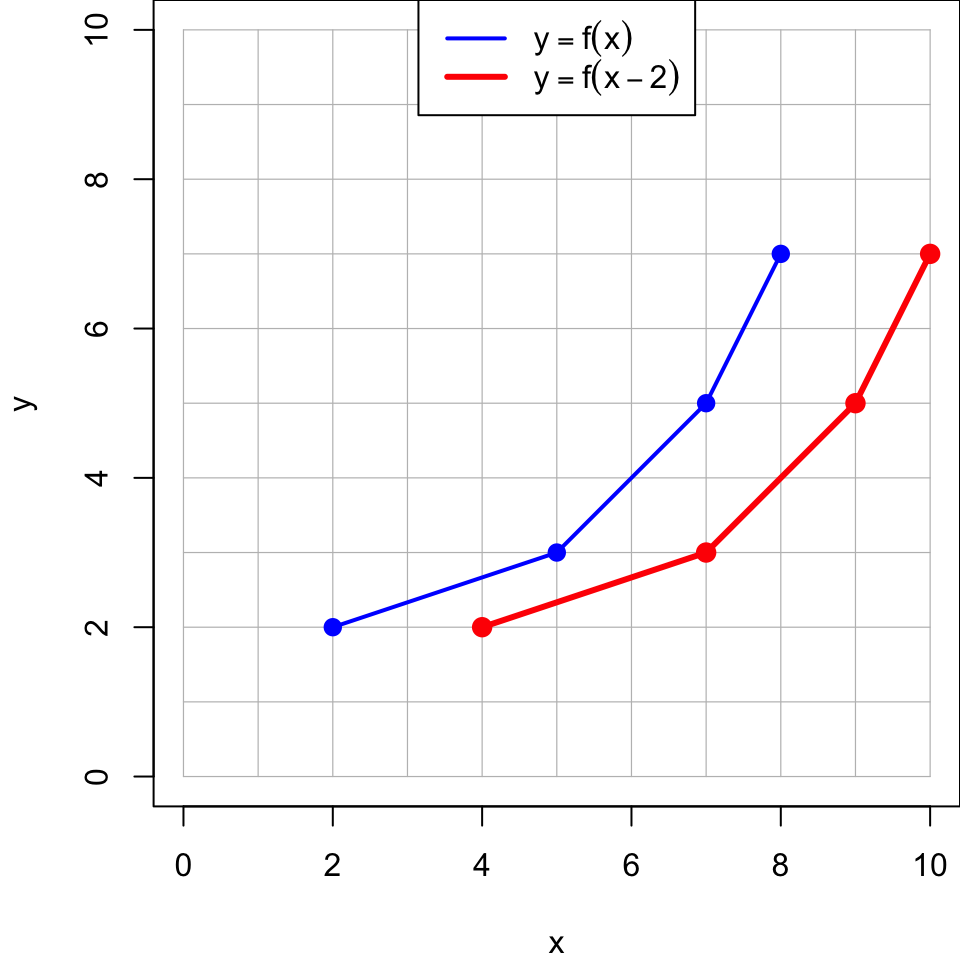

- Note that we shifted (translated) horizontally to the right by 2. In other words, we added 2 to every $x$ value.

# Practice Problem 2

Let function $f$ be defined by the table below:

| $x$ | $f(x)$ |
| --- | --- |
| 1 | 8 |
| 5 | 4 |
| 9 | 7 |

Let function $g$ be defined by the equation below:

$$g(x)~=~f(x+3)$$

Fill out the table below:

| $x$ | $g(x)$ |
| --- | --- |
| $\phantom{\frac{1}{3}+1}$ | $\phantom{\frac{1}{3}+1}$ |
| $\phantom{\frac{1}{3}+1}$ | $\phantom{\frac{1}{3}+1}$ |
| $\phantom{\frac{1}{3}+1}$ | $\phantom{\frac{1}{3}+1}$ |

- Subtract 3 from each value of $x$…

  | $x$ | $g(x)$ |
  | --- | --- |
  | -2 | 8 |
  | 2 | 4 |
  | 6 | 7 |

# Practice Problem 3

Let function $f$ be the squaring function:

$$f(x)~=~x^2$$

When we graph $y=f(x)$, we get an upwards-opening [parabola](https://en.wikipedia.org/wiki/Parabola) with a vertex at $(0,0)$ and a focus at $\left(0,\frac{1}{4}\right)$.

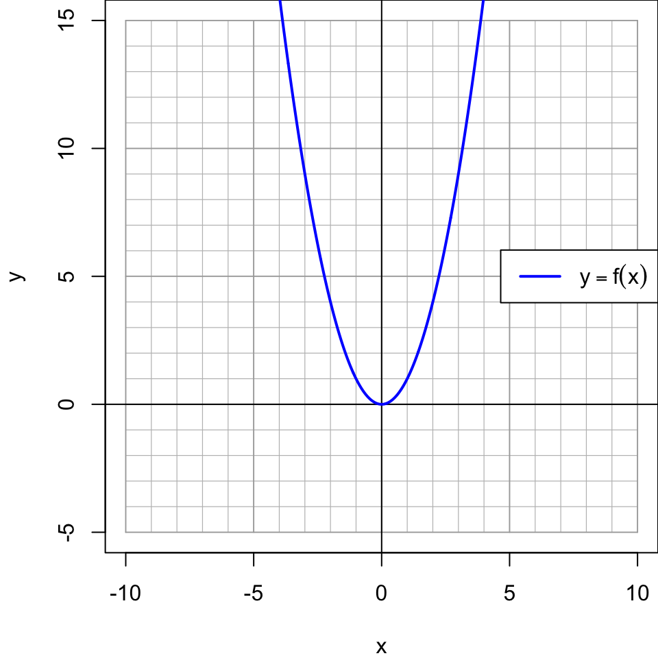

Let function $g$ be defined by the following equation:

$$g(x)~=~f(x+5)$$

In other words, $g(x)=(x+5)^2$. Can you sketch a graph of $y=g(x)$? In other words, can you sketch $y=(x+5)^2$?

- We shift it to the left by 5.

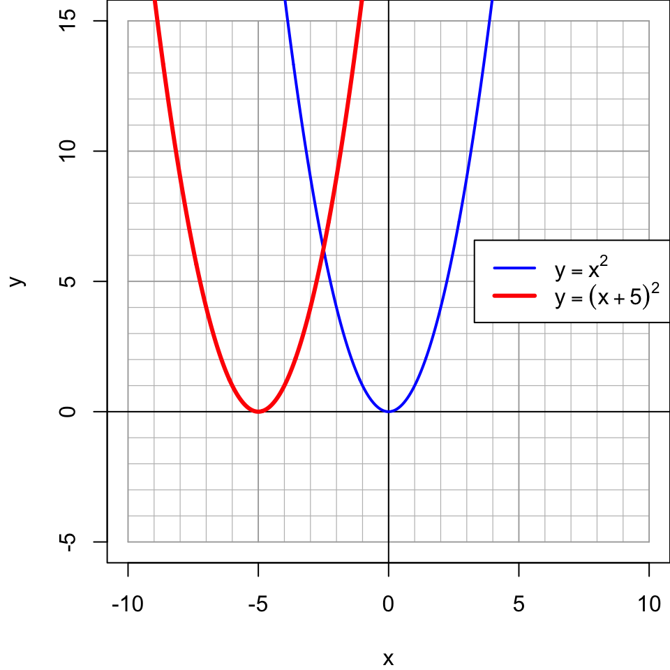

# Vertical Translation

Now for a different variation. Let function $f$ be defined by the table below.

| $x$ | $f(x)$ |
| --- | --- |
| -3 | 16 |
| -2 | 9 |
| -1 | 4 |
| 0 | 1 |
| 1 | 0 |
| 2 | 1 |
| 3 | 4 |

Let function $g$ be defined by the equation below.

$$g(x)=f(x)+10$$

- Can you fill the table below?

  | $x$ | $g(x)$ |
  | --- | --- |
  | $\phantom{\frac{1}{3}+1}$ | $\phantom{\frac{1}{3}+1}$ |
  | $\phantom{\frac{1}{3}+1}$ | $\phantom{\frac{1}{3}+1}$ |
  | $\phantom{\frac{1}{3}+1}$ | $\phantom{\frac{1}{3}+1}$ |
  | $\phantom{\frac{1}{3}+1}$ | $\phantom{\frac{1}{3}+1}$ |
  | $\phantom{\frac{1}{3}+1}$ | $\phantom{\frac{1}{3}+1}$ |
  | $\phantom{\frac{1}{3}+1}$ | $\phantom{\frac{1}{3}+1}$ |
  | $\phantom{\frac{1}{3}+1}$ | $\phantom{\frac{1}{3}+1}$ |

- This transformation is easier to understand. The $x$ values stay the same.
- We can pick $x=-3$ as an example first. Inside the definition of $g$, we replace all values of $x$ with $-3$.
  $$g(-3)=f(-3)+10$$
- We already know that $f(-3)=16$.
  $$g(-3)=16+10$$
  $$g(-3)=26$$
- So we can fill the first row.

  | $x$ | $g(x)$ |
  | --- | --- |
  | -3 | 26 |
  | $\phantom{\frac{1}{3}+1}$ | $\phantom{\frac{1}{3}+1}$ |
  | $\phantom{\frac{1}{3}+1}$ | $\phantom{\frac{1}{3}+1}$ |
  | $\phantom{\frac{1}{3}+1}$ | $\phantom{\frac{1}{3}+1}$ |
  | $\phantom{\frac{1}{3}+1}$ | $\phantom{\frac{1}{3}+1}$ |
  | $\phantom{\frac{1}{3}+1}$ | $\phantom{\frac{1}{3}+1}$ |
  | $\phantom{\frac{1}{3}+1}$ | $\phantom{\frac{1}{3}+1}$ |

- So, what about the rest of the table?
- We just add 10 to all the $f$ outputs to get the $g$ outputs.

  | $x$ | $g(x)$ |
  | --- | --- |
  | -3 | 26 |
  | -2 | 19 |
  | -1 | 14 |
  | 0 | 11 |
  | 1 | 10 |
  | 2 | 11 |
  | 3 | 14 |

# Practice problem 4

Let function $f$ represent [the square-root function](https://en.wikipedia.org/wiki/Square_root#Properties_and_uses).

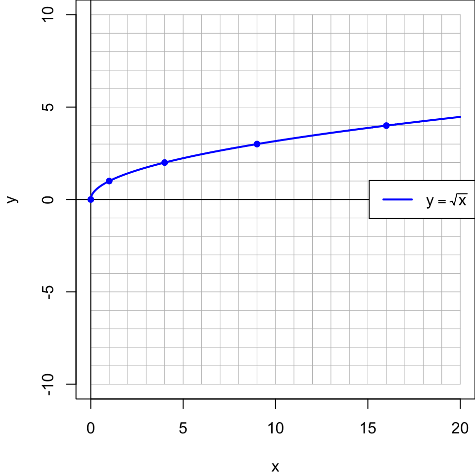

- How would you graph $y=\sqrt{x}-8$?
- The curve shifts down by 8.

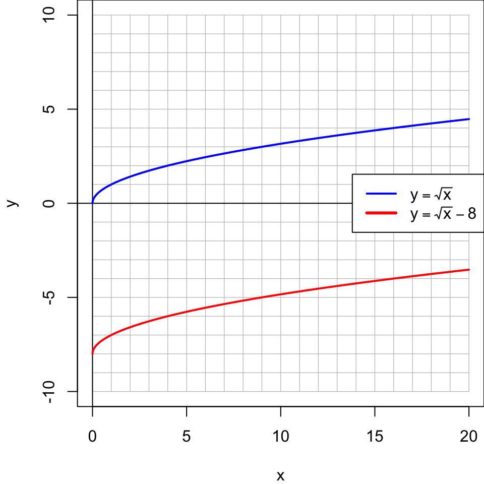

- How do you graph $y=\sqrt{x-8}$?
- Since the subtraction of 8 happens BEFORE the square-root function, this causes a horizontal shift to the right.

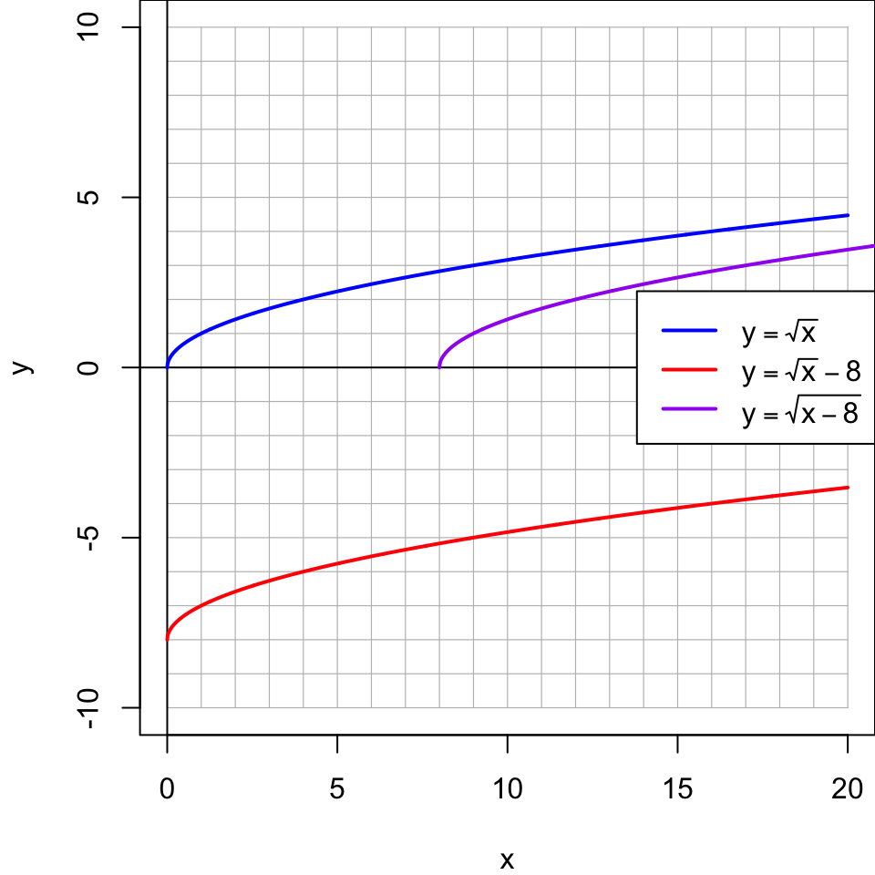

# Summary

- Adding/subtracting a constant **inside** the function (so the addition happens before the function is applied) causes a horizontal shift. Adding a positive number inside causes a leftward shift.
- Adding/subtracting a constant **outside** the function (so the addition happens after the function is applied) causes a vertical shift. Adding a positive number outside causes an upward shift.
- Visual example with function notation:

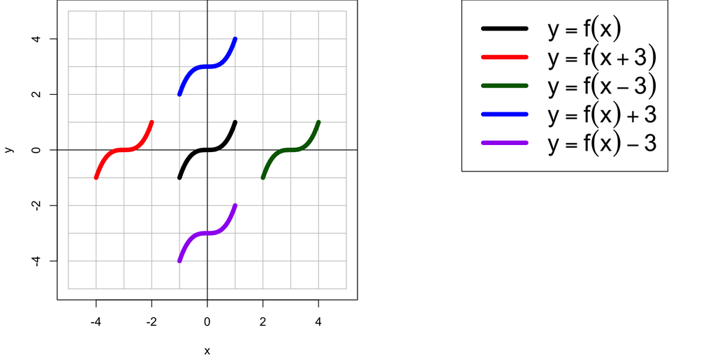

- Visual example with square-root function:

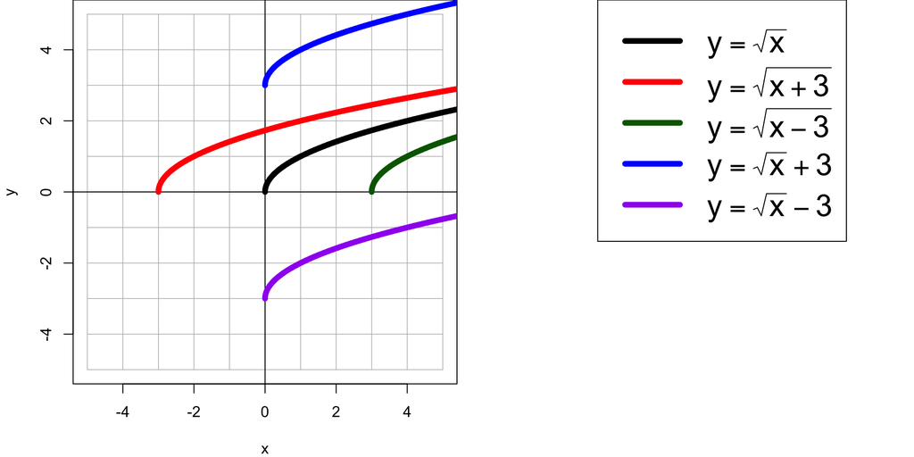